# R Notebook

- You have been provided some customer data from a shopping centre. Do some exploratory analysis on the data. Comment on findings.
- We are interested in creating a marketing campaign to target customers based on their spending score and annual income. Perform a k-means clustering to find if there are meaningful clusters in the data to target the customers.

```r
library(tidyverse)
library(janitor)
```

```r
customers <- read_csv("clustering_homework/mall_customers.csv")
customers
```

| CustomerID | Gender | Age | Annual Income (k$) | Spending Score (1-100) |
| --- | --- | --- | --- | --- |
| 1 | Male | 19 | 15 | 39 |
| 2 | Male | 21 | 15 | 81 |
| 3 | Female | 20 | 16 | 6 |
| 4 | Female | 23 | 16 | 77 |
| 5 | Female | 31 | 17 | 40 |
| 6 | Female | 22 | 17 | 76 |
| 7 | Female | 35 | 18 | 6 |
| 8 | Female | 23 | 18 | 94 |
| 9 | Male | 64 | 19 | 3 |
| 10 | Female | 30 | 19 | 72 |

[output cut: 190 more lines]

```r
customers <-customers %>%
  clean_names()
```

- Perform k-means clustering and chose a value of k. #select on variables to be investigated in method

```r
customers <- customers  %>%
              select(c(annual_income_k, spending_score_1_100))
summary(customers)
```

```
 annual_income_k  spending_score_1_100
 Min.   : 15.00   Min.   : 1.00
 1st Qu.: 41.50   1st Qu.:34.75
 Median : 61.50   Median :50.00
 Mean   : 60.56   Mean   :50.20
 3rd Qu.: 78.00   3rd Qu.:73.00
 Max.   :137.00   Max.   :99.00
```

plot to look for clustering: ##looks like 5 potential clusters

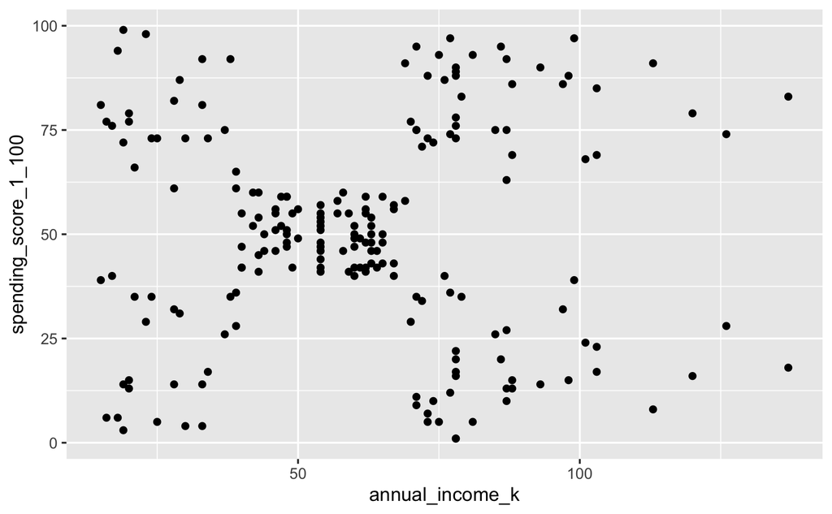

```r
customers %>%
ggplot(aes(annual_income_k, spending_score_1_100)) +
  geom_point()
```

#scale

```r
customers_scale <- customers %>%
                      mutate_all(scale)

summary(customers_scale)
```

```
  annual_income_k.V1  spending_score_1_100.V1
 Min.   :-1.7346462   Min.   :-1.9052398
 1st Qu.:-0.7256883   1st Qu.:-0.5982918
 Median : 0.0357895   Median :-0.0077449
 Mean   : 0.0000000   Mean   : 0.0000000
 3rd Qu.: 0.6640086   3rd Qu.: 0.8829160
 Max.   : 2.9103678   Max.   : 1.8897500
```

#k-means calculation. k = 5, n =10(more than but not so much to impact computing time)

```r
clustered_customers <- kmeans(customers_scale, centers = 5, nstart = 10)
clustered_customers
```

[output not shown]

```r
library(broom)

tidy(clustered_customers,
     col.names = colnames(customers_scale))
```

```r
glance(clustered_customers)
```

```r
augment(clustered_customers, customers)
```

```r
# Set min & max number of clusters want to look at
max_k <- 20

k_clusters_customers <- tibble(k = 1:max_k) %>%
  mutate(
    kclust = map(k, ~ kmeans(customers_scale, .x, nstart = 25)),
    tidied = map(kclust, tidy),
    glanced = map(kclust, glance),
    augmented = map(kclust, augment, customers)
  )

k_clusters_customers
```

```r
clusterings <- k_clusters_customers%>%
  unnest(glanced)

clusterings
```

plot results

```r
ggplot(clusterings, aes(x=k, y=tot.withinss)) +
  geom_point() +
    geom_line() +
    scale_x_continuous(breaks = seq(1, 20, by = 1))
```

[output not shown]

quicker method for all 3

```r
library(factoextra)

#elbow
fviz_nbclust(customers_scale, kmeans, method = "wss", nstart = 25)
```

[output not shown]

```r
#silhouetter
fviz_nbclust(customers_scale, kmeans, method = "silhouette", nstart = 25)
```

[output not shown]

```r
#gap statistic
fviz_nbclust(customers_scale, kmeans, method = "gap_stat", nstart = 25, k.max = 10)
```

[output not shown]

- Visualise the clustering for your chosen value of k. #visualise k value. k =7? but previous ,ethods support 5

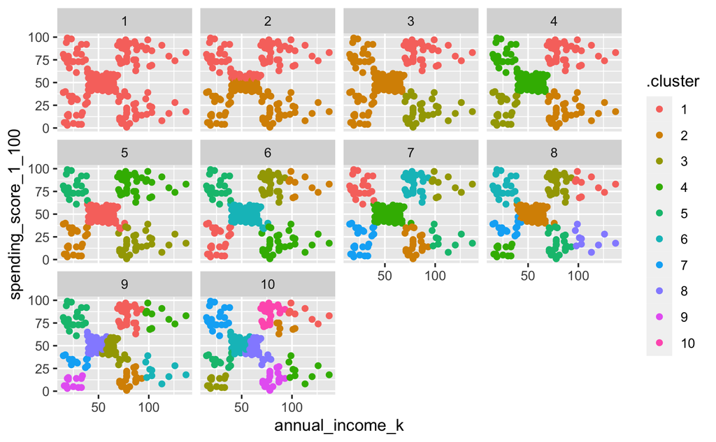

```r
 clusterings %>%
  unnest(cols = c(augmented)) %>%
  filter(k <= 10) %>%
 ggplot(aes(x = annual_income_k, y = spending_score_1_100)) +
  geom_point(aes(color = .cluster)) +
  facet_wrap(~ k)
```

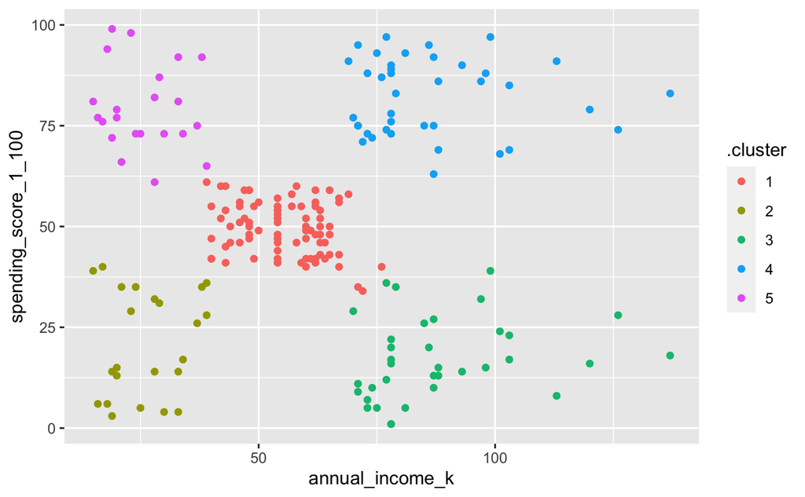

```r
 clusterings %>%
  unnest(cols = c(augmented)) %>%
  filter(k == 5) %>%
 ggplot(aes(x = annual_income_k,
            y = spending_score_1_100,
            colour = .cluster)) +
   geom_point(aes(color = .cluster)) #+
```

```r
  #geom_text(hjust = 0, vjust = - 0.5, size = 3)
```

- Do you think the clustering seems a good fit for this data? Yes
- Comment on the attributes on one or two of the clusters (maybe even give them a label if you like - like in section 4.1 of the ‘Segmentation & clustering intro’ lesson).

#cluster 1- mid income